# Data Summary: Automatic Feeder Survey Data

Kota Minegishi

Created: April 18, 2017

# 1 Objective

- Summarize and explore survey records

# 2 Data

- Questionnaire on automated calf feeders and associated group housing facilities, for project cooperator dairy operations.
- Collected and maintained by Marcia Endres, Bill Lazarus, and Matt Jorgensen.

```r
library(dplyr)
library(tidyr)
library(ggplot2)
library(lazyeval)
load("survey_data.RData")
```

To manage data, *variables* are created for survey questions, which are separated from the survey data. The question-variable key table is the following;

```r
question_key %>%
  mutate(
    question = substr(question, 1, 75)
  )
```

| q_num | variable | question |
| --- | --- | --- |
| 1 | farm_id | Farm identification numbers from the questionnaires |
| 2 | days_on_feeder | Days on feeder/group |
| 2b | days_on_feeder_clean | Days per turn including cleanup |
| NA | turns_year | Turns/year |
| 3 | feeder_make | What is the make and model of the feeder installed? |
| 4 | using_since_year | When did you put the feeder into operation? - year |
| 4b | using_since_mon | When did you put the feeder into operation? - month |
| 5 | calves_total | How many calves are being fed with the feeder currently? |
| 5b | num_feeders | Feeders now |
| 5c | feeders_planned | Feeders planned for the long run |

[output cut: 31 more lines]

`survey_current` has 35 observations and 66 variables;

```r
summary(survey_current)
```

```
   farm_id          days_on_feeder days_on_feeder_clean   turns_year     feeder_make        using_since_year
 Length:35          Min.   :51.0   Min.   : 0.000       Min.   :0.0000   Length:35          Min.   :2007
 Class :character   1st Qu.:55.0   1st Qu.: 0.000       1st Qu.:0.0000   Class :character   1st Qu.:2009
 Mode  :character   Median :55.0   Median : 0.000       Median :0.0000   Mode  :character   Median :2010
                    Mean   :54.8   Mean   : 3.171       Mean   :0.3773                      Mean   :2010
                    3rd Qu.:55.0   3rd Qu.: 0.000       3rd Qu.:0.0000                      3rd Qu.:2012
                    Max.   :55.0   Max.   :59.000       Max.   :7.0192                      Max.   :2012

 using_since_mon   calves_total    num_feeders    feeders_planned num_calves_planned building_change
 Min.   : 1.000   Min.   :  7.0   Min.   :1.000   Min.   :1.00    Min.   :200        Length:35
 1st Qu.: 4.000   1st Qu.: 25.5   1st Qu.:1.000   1st Qu.:1.75    1st Qu.:200        Class :character
 Median : 7.000   Median : 36.0   Median :1.000   Median :2.50    Median :200        Mode  :character
 Mean   : 6.828   Mean   : 52.6   Mean   :1.156   Mean   :2.50    Mean   :200
 3rd Qu.: 8.000   3rd Qu.: 50.0   3rd Qu.:1.000   3rd Qu.:3.25    3rd Qu.:200
 Max.   :12.000   Max.   :350.0   Max.   :3.000   Max.   :4.00    Max.   :200
 NA's   :6                        NA's   :3       NA's   :33      NA's   :34
    change          investment_ini   feeder_cost_total building_cost    additional_inv      when_add_on    cost_add_on
 Length:35          Min.   : 12000   Min.   :11000     Min.   :     0   Length:35          Min.   :2009   Min.   :  750
 Class :character   1st Qu.: 30000   1st Qu.:14632     1st Qu.: 10000   Class :character   1st Qu.:2012   1st Qu.: 1500
 Mode  :character   Median : 40825   Median :16250     Median : 20575   Mode  :character   Median :2012   Median : 2000
                    Mean   : 80902   Mean   :20489     Mean   : 59265                      Mean   :2012   Mean   : 4828
                    3rd Qu.: 80191   3rd Qu.:20000     3rd Qu.: 65664                      3rd Qu.:2013   3rd Qu.: 2000
                    Max.   :600000   Max.   :80000     Max.   :540000                      Max.   :2013   Max.   :27400
                    NA's   :1        NA's   :1         NA's   :1                           NA's   :25     NA's   :26
  life_feeder    life_building    life_add_on    repair_cost_feeder repair_cost_building  labor_feeder
 Min.   : 9.00   Min.   :10.00   Min.   :12.50   Min.   :    0      Min.   :   0.0       Min.   : 0.1667
 1st Qu.:10.00   1st Qu.:20.00   1st Qu.:13.75   1st Qu.:  250      1st Qu.:   0.0       1st Qu.: 0.5500
 Median :12.50   Median :25.00   Median :15.00   Median :  500      Median : 100.0       Median : 1.0000
 Mean   :13.78   Mean   :28.04   Mean   :25.83   Mean   : 1910      Mean   : 391.7       Mean   : 2.0253
 3rd Qu.:16.88   3rd Qu.:36.25   3rd Qu.:32.50   3rd Qu.:  727      3rd Qu.: 350.0       3rd Qu.: 2.5000
 Max.   :20.00   Max.   :50.00   Max.   :50.00   Max.   :30000      Max.   :4000.0       Max.   :10.0000
 NA's   :5       NA's   :7       NA's   :32      NA's   :6          NA's   :11           NA's   :3
 labor_repairs    was_last_year_typical      wage         mortality       value_calf_in   value_calf_out   feed_day_hd
 Min.   :  0.00   Length:35             Min.   : 8.50   Min.   :0.00000   Min.   : 80.0   Min.   :225.0   Min.   :0.900
 1st Qu.:  1.75   Class :character      1st Qu.:12.75   1st Qu.:0.01000   1st Qu.:103.8   1st Qu.:300.0   1st Qu.:1.417
 Median :  3.50   Mode  :character      Median :15.00   Median :0.02000   Median :150.0   Median :350.0   Median :2.232
 Mean   : 21.77                         Mean   :16.25   Mean   :0.02881   Mean   :173.0   Mean   :358.4   Mean   :2.269
 3rd Qu.: 12.00                         3rd Qu.:19.00   3rd Qu.:0.05000   3rd Qu.:200.0   3rd Qu.:400.0   3rd Qu.:2.864
 Max.   :300.00                         Max.   :25.00   Max.   :0.07000   Max.   :300.0   Max.   :500.0   Max.   :4.000
 NA's   :3                              NA's   :8       NA's   :2         NA's   :5       NA's   :5       NA's   :15
```

[output cut: 25 more lines]

```
 Min.   :6.083   Min.   :  42.58   Min.   :11000   Min.   : 12000   Min.   :  962.9   Min.   :  5.071   Min.   : 0.000
 1st Qu.:6.083   1st Qu.: 155.12   1st Qu.:14582   1st Qu.: 30000   1st Qu.: 2407.3   1st Qu.:  8.904   1st Qu.: 2.301
 Median :6.083   Median : 219.00   Median :16250   Median : 42548   Median : 3414.1   Median : 17.523   Median : 2.877
 Mean   :6.105   Mean   : 320.89   Mean   :17384   Mean   : 79755   Mean   : 6399.7   Mean   : 24.876   Mean   : 4.731
 3rd Qu.:6.083   3rd Qu.: 304.17   3rd Qu.:20000   3rd Qu.: 80191   3rd Qu.: 6434.7   3rd Qu.: 25.893   3rd Qu.: 6.955
 Max.   :6.518   Max.   :2129.17   Max.   :26667   Max.   :558000   Max.   :44775.4   Max.   :184.008   Max.   :13.151
                                   NA's   :3       NA's   :1        NA's   :1         NA's   :1         NA's   :14
  labor_total        labor_calf      operating_calf    cost_calf     net_return_calf   calves_gr       mortality_gr
 Min.   :  972.5   Min.   :  4.702   Min.   :135.5   Min.   :482.9   Min.   :-664.67   1-30 :14   < 2.0 %    :18
 1st Qu.: 2916.2   1st Qu.: 17.667   1st Qu.:267.9   1st Qu.:542.0   1st Qu.:-432.90   31-60:14   2.1 - 3.0 %: 4
 Median : 6716.3   Median : 35.739   Median :313.9   Median :601.1   Median :-201.13   61-90: 2   3.1 - 4.0 %: 2
 Mean   :12120.1   Mean   : 42.848   Mean   :384.5   Mean   :678.6   Mean   :-282.90   91+  : 5   4.1 - 5.0 %: 5
 3rd Qu.:19556.2   3rd Qu.: 69.034   3rd Qu.:430.5   3rd Qu.:776.4   3rd Qu.: -92.02              > 5.0 %    : 4
 Max.   :42840.6   Max.   :122.055   Max.   :774.7   Max.   :951.7   Max.   :  17.09              NA's       : 2
 NA's   :11        NA's   :11        NA's   :31      NA's   :32      NA's   :32
```

Similarly, `survey_planned` has 8 observations and 66 variables; many variables are missing.

# 3 Data plots

Unless we impute missing information, there are not many data points. It also appears that these farms may not raise calves primarily for profit from calf sales. In that case, we may not see much economic explanation for varying practices across farms.

## 3.1 Value of calf after being fed

So far the most interesting plot is the one with the **values of a calf coming in** and **going out** of the feeding operation.

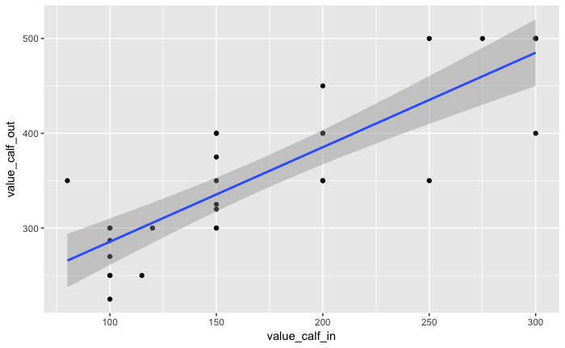

```r
survey_current %>%
  ggplot(aes(x = value_calf_in, y = value_calf_out)) +
  geom_point() +
  geom_smooth(method="lm")
```

However, the final (expected) calf price does not seem to be correlated with the costs of capital investment, labor, repairs, and feed ingredients.

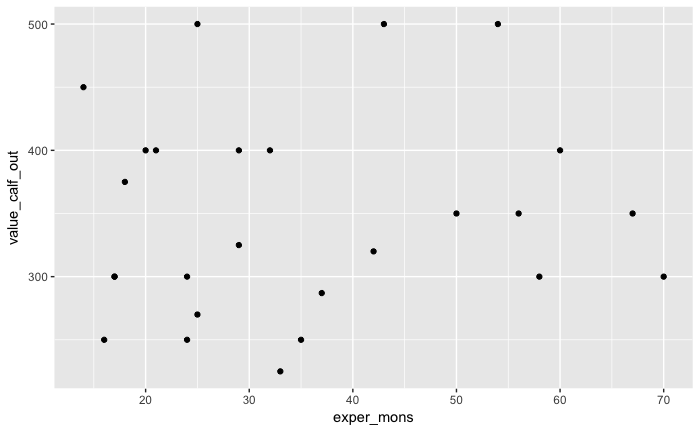

```r
survey_current %>%
  ggplot(aes(x = exper_mons, y = value_calf_out)) +
  geom_point()
```

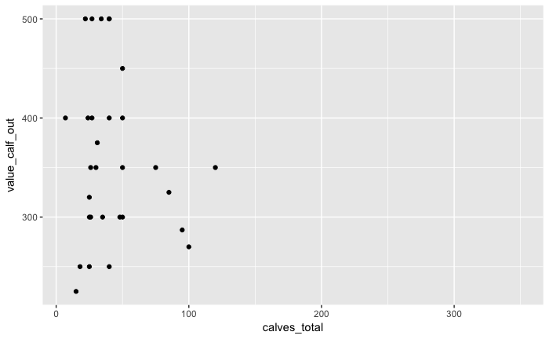

```r
survey_current %>%
  ggplot(aes(x = calves_total, y = value_calf_out)) +
  geom_point()
```

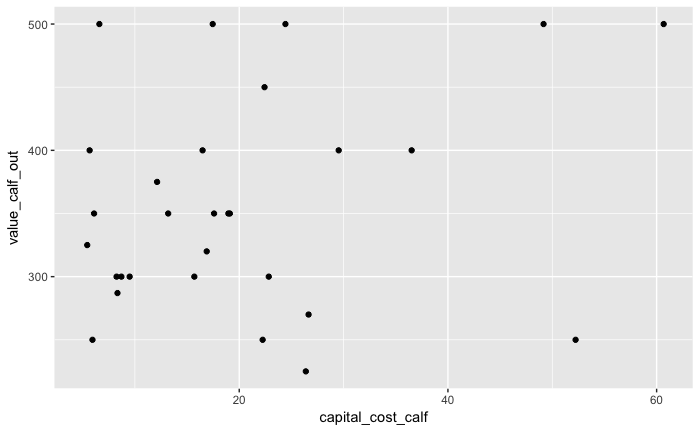

```r
survey_current %>%
  filter(capital_cost_calf < 100) %>%
  ggplot(aes(x = capital_cost_calf, y = value_calf_out)) +
  geom_point()
```

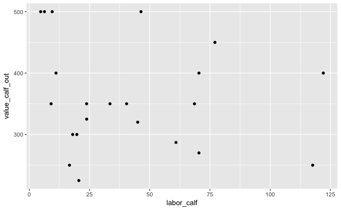

```r
survey_current %>%
  ggplot(aes(x = labor_calf, y = value_calf_out )) +
  geom_point()
```

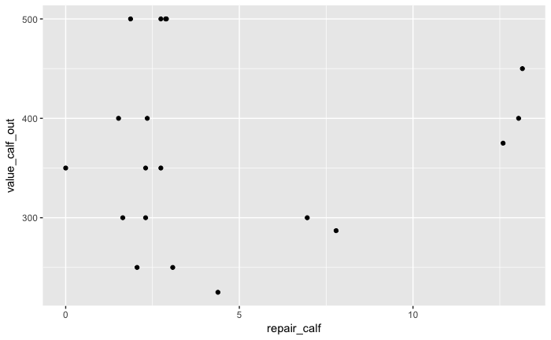

```r
survey_current %>%
  ggplot(aes(x = repair_calf, y = value_calf_out )) +
  geom_point()
```

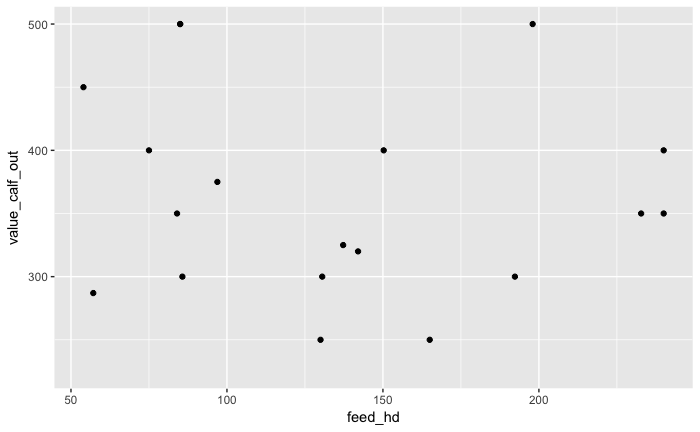

```r
survey_current %>%
  ggplot(aes(x = feed_hd, y = value_calf_out)) +
  geom_point()
```

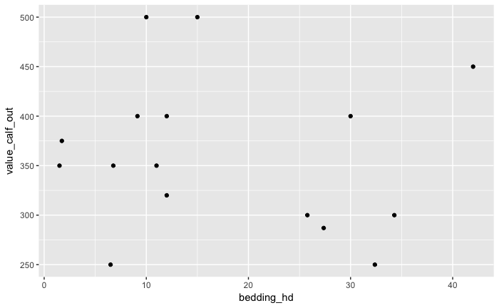

```r
survey_current %>%
  filter(bedding_hd < 50) %>%
  ggplot(aes(x = bedding_hd, y = value_calf_out)) +
  geom_point()
```

## 3.2 Mortality

No obvious patterns are found in the mortality rate across farms.

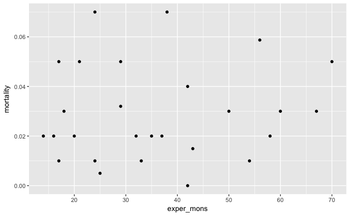

```r
survey_current %>%
  ggplot(aes(x = exper_mons, y = mortality)) +
  geom_point()
```

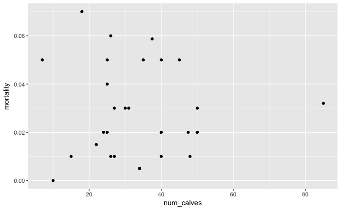

```r
survey_current %>%
  ggplot(aes(x = num_calves, y = mortality)) +
  geom_point()
```

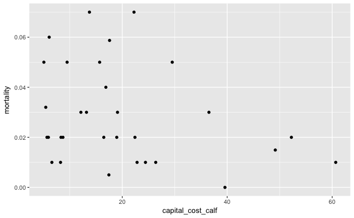

```r
survey_current %>%
  filter(capital_cost_calf < 100) %>%
  ggplot(aes(x = capital_cost_calf, y = mortality)) +
  geom_point()
```

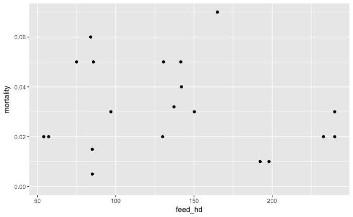

```r
survey_current %>%
  ggplot(aes(x = feed_hd, y = mortality)) +
  geom_point()
```

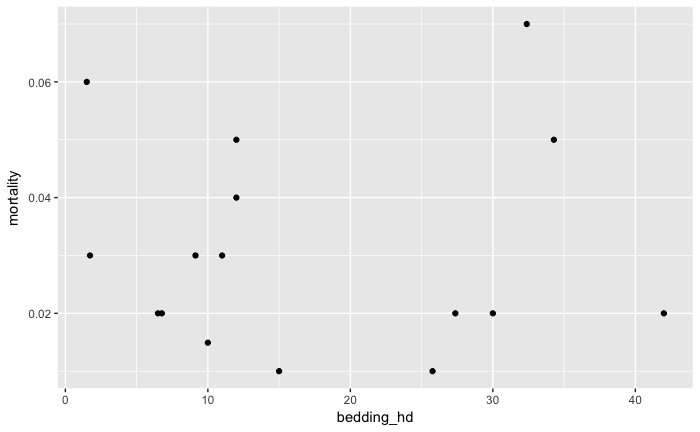

```r
survey_current %>%
  filter(bedding_hd < 50) %>%
  ggplot(aes(x = bedding_hd, y = mortality)) +
  geom_point()
```

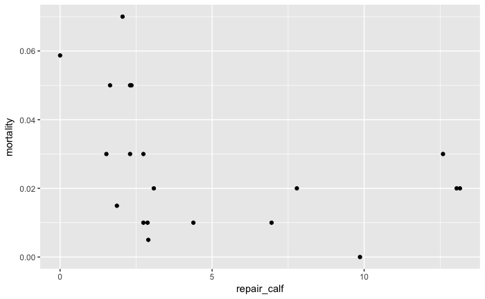

```r
survey_current %>%
  ggplot(aes(x = repair_calf, y = mortality)) +
  geom_point()
```

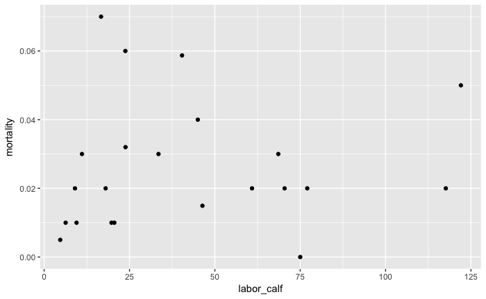

```r
survey_current %>%
  ggplot(aes(x = labor_calf, y = mortality)) +
  geom_point()
```

## 3.3 Labor and Capital

Some have invested more on the system than others. Higher capital cost, however, does not seem to be related to higher labor efficiency or lower mortality. (Probably it has to do with the cost of remodeling the barn etc.)

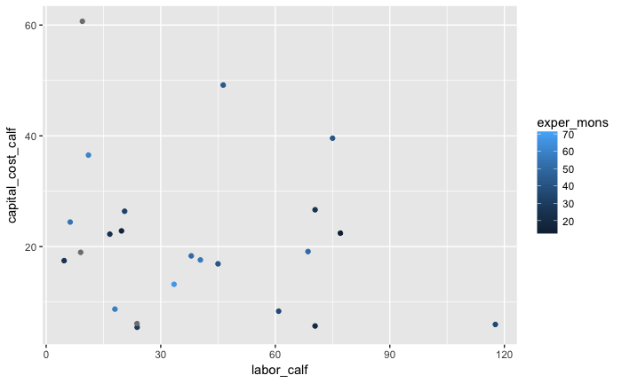

```r
survey_current %>%
  filter(capital_cost_calf < 100) %>%
  ggplot(aes(x = labor_calf, y = capital_cost_calf)) +
  geom_point(aes(color = exper_mons))
```

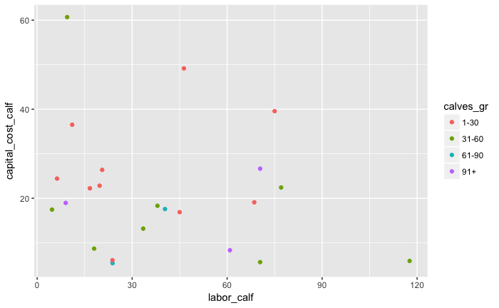

```r
survey_current %>%
  filter(capital_cost_calf < 100) %>%
  ggplot(aes(x = labor_calf, y = capital_cost_calf)) +
  geom_point(aes(color = calves_gr))
```

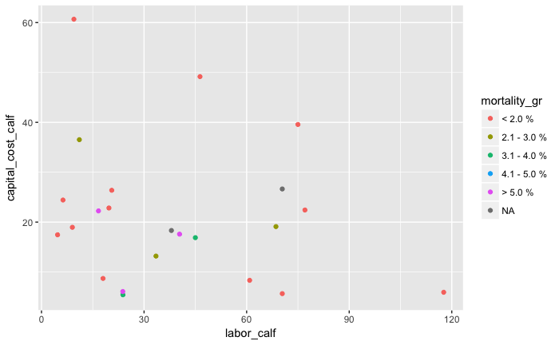

```r
survey_current %>%
  filter(capital_cost_calf < 100) %>%
  ggplot(aes(x = labor_calf, y = capital_cost_calf)) +
  geom_point(aes(color = mortality_gr))
```

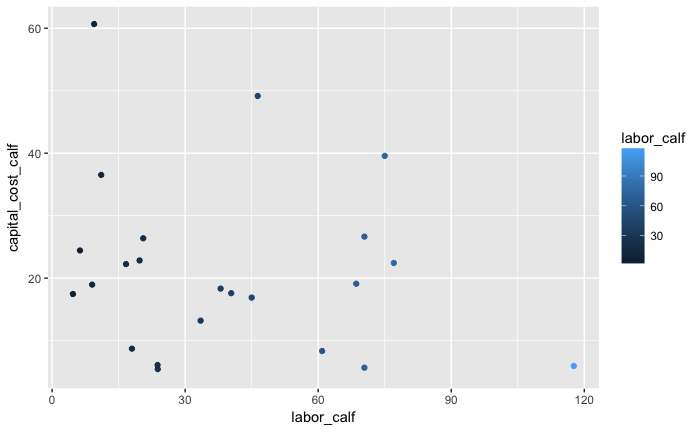

```r
survey_current %>%
  filter(capital_cost_calf < 100) %>%
  ggplot(aes(x = labor_calf, y = capital_cost_calf)) +
  geom_point(aes(color = labor_calf))
```